# Normal and Exponential Distributions

Applied Statistics

MTH-361A | Spring 2025 | University of Portland

February 21, 2025

# Objectives

- **Develop and understanding of the exponential and normal distributions**
- **Know how to compute exponential and normal probabilities using R**
- **Introduce how to simulate exponential and normal random sampling in R**
- **Activity: The Galton Board and Normal Distribution**

# Previously…

**The Law of Large Numbers**

It states that as the number of trials in a random experiment increases, the sample mean approaches the expected value.

**Example Bernoulli Trials Simulation**

Let $p=0.60$ be the “success” probability of a Bernoulli r.v. $X$, where $\text{E}(X) = p$.

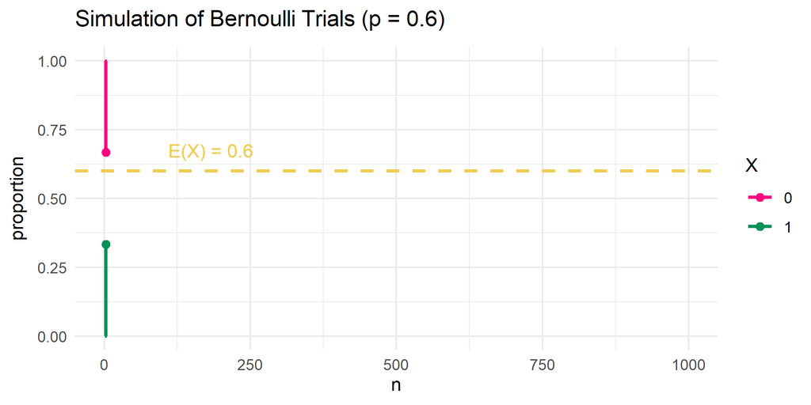

# Visualizing the Exponential Distribution

**Exponential Distribution**

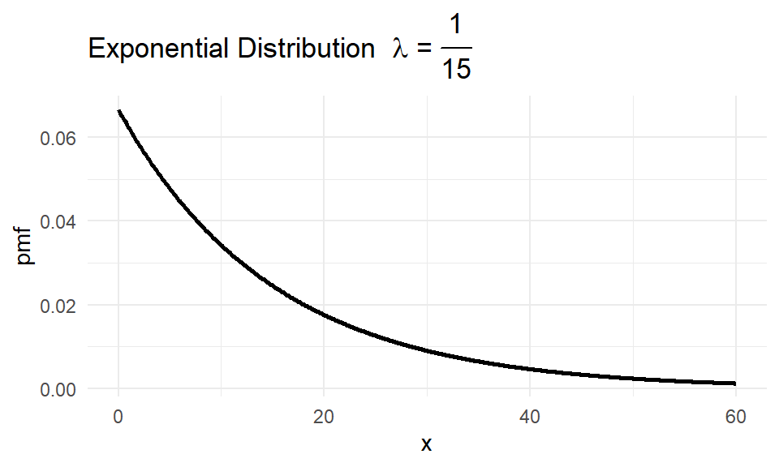

**Exponential R.V.**

Let $\lambda=\frac{1}{15}$ be the rate of “success”.

$$\begin{aligned}
\text{R.V. } & \longrightarrow X \sim
\text{Exp}\left(\frac{1}{15}\right) \\
\text{PDF } & \longrightarrow f(x) = \frac{1}{15} e^{- \frac{1}{15}
x} \\
\text{for } & x \in [0,\infty)
\end{aligned}$$

# Exponential Probabilities

**Exponential Distribution**

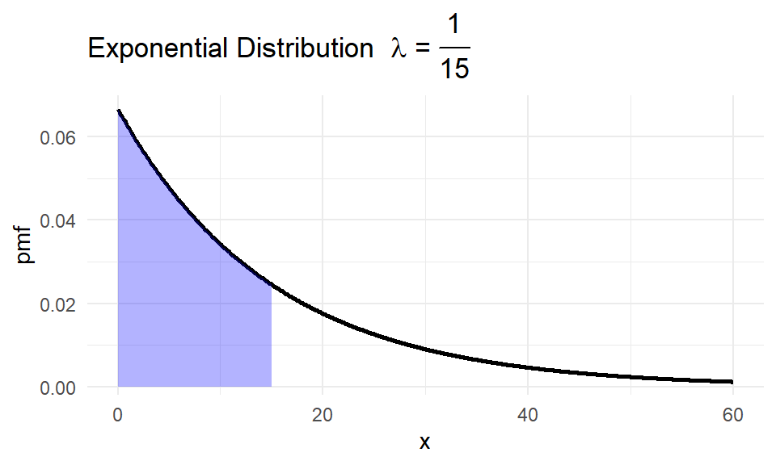

**Example:**

What is the probability that “success” happens on 15 unit length or less, given $\lambda=\frac{1}{15}$?
$$\begin{aligned}
P(X \le 15) & = \int_0^{15} f(x) \ dx \\
& = \int_0^{15} \frac{1}{15} e^{-\frac{1}{15} x} \ dx \\
P(X \le 15) & \approx 0.632
\end{aligned}$$

**Using R:**

```r
lambda <- 1/15
pexp(15,lambda)
```

```
## [1] 0.6321206
```

$\star$ Note that the `pexp()` function computes the probability $P(X \le x)$, meaning it computes the sum of all probabilities from $X=0$ to $X=x$ using the Exponential PDF. The `dexp()` function computes the density, not probability because $P(X = x)=0$ at any $x$.

# Exponential Expected Value

**Exponential Distribution with Expected Value**

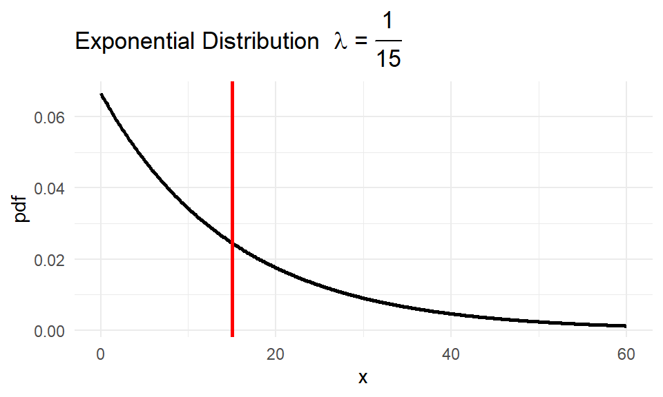

**Exponential R.V.**

Let $\lambda=\frac{1}{15}$ be the rate of “success”.

$$\begin{aligned}
\text{R.V. } & \longrightarrow X \sim
\text{Exp}\left(\frac{1}{15}\right) \\
\text{PDF } & \longrightarrow f(x) = \frac{1}{15} e^{- \frac{1}{15}
x} \\
\text{for } & x \in [0,\infty) \\
\text{expected value} & \longrightarrow \text{E}(X) = 15
\end{aligned}$$

In general, the expected value of the exponential r.v. is given by
$$\text{E}(X) = \frac{1}{\lambda},$$
which is the reciprocal of the “success” rate.

# Simulating the Exponential Distribution

**Random Sampling from the Exponential Distribution**

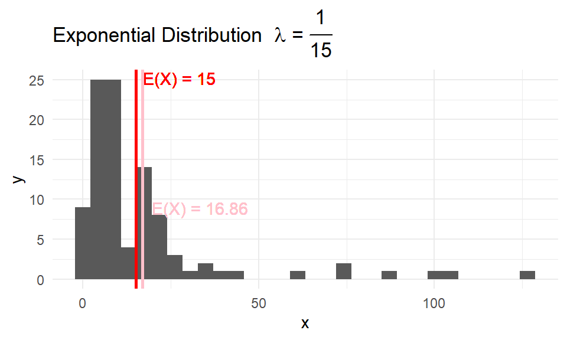

**Sample Mean vs the Expected Value**

```r
N <- 100 # number of simulations
mean <- 15
lambda <- 1/15 # set rate
rexp(N,lambda)
```

# Binomial R.V. (Revisited)

**Binomial Distribution**

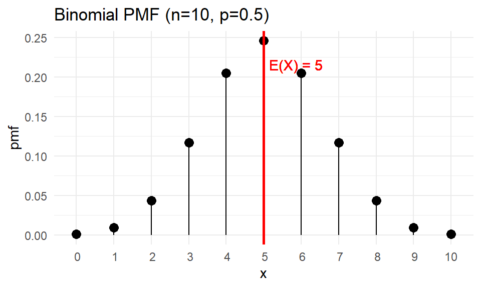

**Binomial R.V.**

Let $p=0.50$ be the success probability and $n=10$ the number of trials.

$$\begin{aligned}
\text{R.V. } & \longrightarrow X \sim \text{Binom}(n,p) \\
\text{PMF } & \longrightarrow P(X=k) = \binom{n}{k} p^k (1-p)^{n-k}
\\
\text{for } & k = 0,1,2,3, \cdots, n \\
\text{expected value} & \longrightarrow \text{E}(X) \approx 5
\end{aligned}$$

# Flipping $\mathbf{n}$ Coins: Possible Outcomes

Suppose we conduct an experiment of flipping $n$ fair coins in a sequence, where $n$ is an integer. The sample space $S$ contains all possible sequences of $H$ and $T$. Number of possible outcomes is $|S| = 2^n$.

**Visualizing the possible outcomes using Pascal’s triangle**

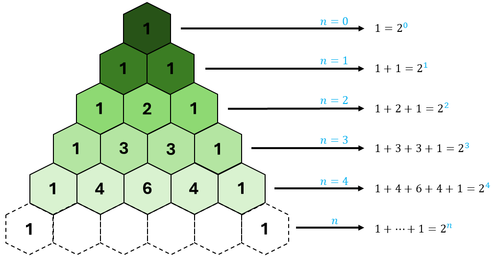

$\star$ **Key Idea:** Pascal’s Triangle helps us visualize the total possible sequences of “success” ($H$) outcomes given $n$ independent trials.

# Flipping $\mathbf{n}$ Coins: Counting the Number of $H$ outcomes

Let $X$ be the r.v. that counts the number of $H$ outcomes in $n$ trials.

**Pascal’s triangle helps us count**

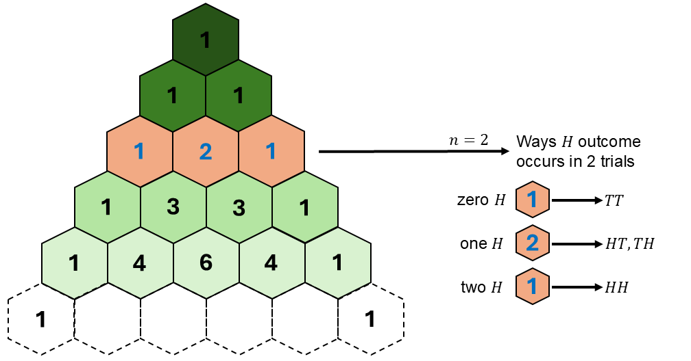

$\dagger$ Can you determine the ways $H$ can occur in $4$ trials using Pascal’s triangle?

# Flipping $\mathbf{n}$ Coins: Probability of Observing $H$ outcomes in $n$ Trials

Compute the probability of observing a certain number of “success” ($H$) outcomes in $n$ trials.

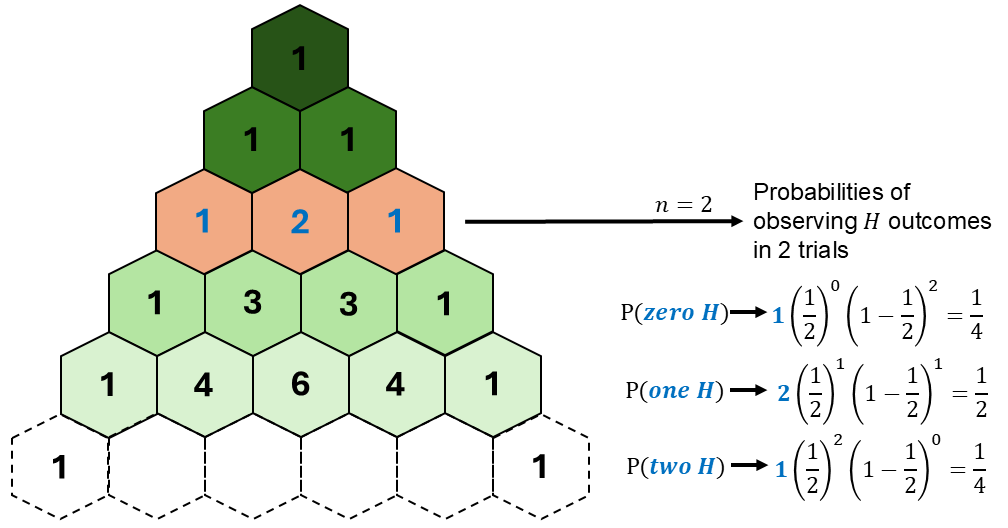

$\dagger$ Can you determine the probabilities of observing $H$ outcomes in $4$ trials?

# Flipping $\mathbf{n}$ Coins: The Expected Number of $H$ outcomes in $n$ Trials

How many $H$ outcomes do we expect to have in $n$ independent Bernoulli trials with “success” probability $p$?

**Example**

- Each fair coin flip is an independent Bernoulli trial with:
  - $P(H) = \frac{1}{2}$
  - $P(T) = 1 - \frac{1}{2}$
- Suppose that $n=2$.
  - We expect to have $2 \times \frac{1}{2} = 1$ $H$ outcome in $2$ trials.

**In general:**

- The expected value of “success” outcomes is $\text{E}(X) = n \times p$.
- The binomial coefficient tells you how many ways $k$ “success” outcomes can occur in $n$ trials, corresponding to the $k$-th column in the $n$-th row of Pascal’s Triangle.

$\star$ **Key Idea:** Over many repetitions, the long-run average number of “success” outcomes is $n \times p$, reflecting the frequentist interpretation of probability.

# Normal Approximation to the Binomial

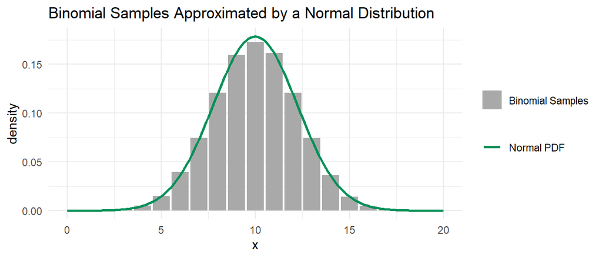

# The Normal R.V.

A **normal r.v.** is a type of continuous r.v. whose probability distribution follows the *normal distribution*, also known as the *Gaussian distribution*. The normal distribution is characterized by two parameters, $\mu$ as the mean and $\sigma^2$ as the variance:
$$X \sim \text{N}(\mu,\sigma^2)$$

**Sample Space:**

- $x \in (-\infty,\infty)$ because the normal r.v. can take any value from the entire real number line and it is a continuous random variable.

**Parameters**

- $\mu$ is the mean (center) or the mode of the distribution.
- $\sigma^2$ measures the spread of the distribution.

# The Normal R.V.: PDF

The normal r.v. $X \sim \text{N}(\mu,\sigma^2)$ has infinite possible outcomes (or infinite sized sample space) where $\mu$ is the mean and $\sigma^2$ is the variance with PDF given as
$$f(x) = \frac{1}{\sqrt{2 \pi \sigma^2}}
e^{-\frac{(x-\mu)^2}{2\sigma^2}}, \ -\infty < x <
\infty$$

$\star$ **Key Idea:** The normal r.v. often approximates the distribution of many types of data, especially when there are large numbers of independent factors contributing to the outcome.

# Normal Probabilities

**Normal Distribution**

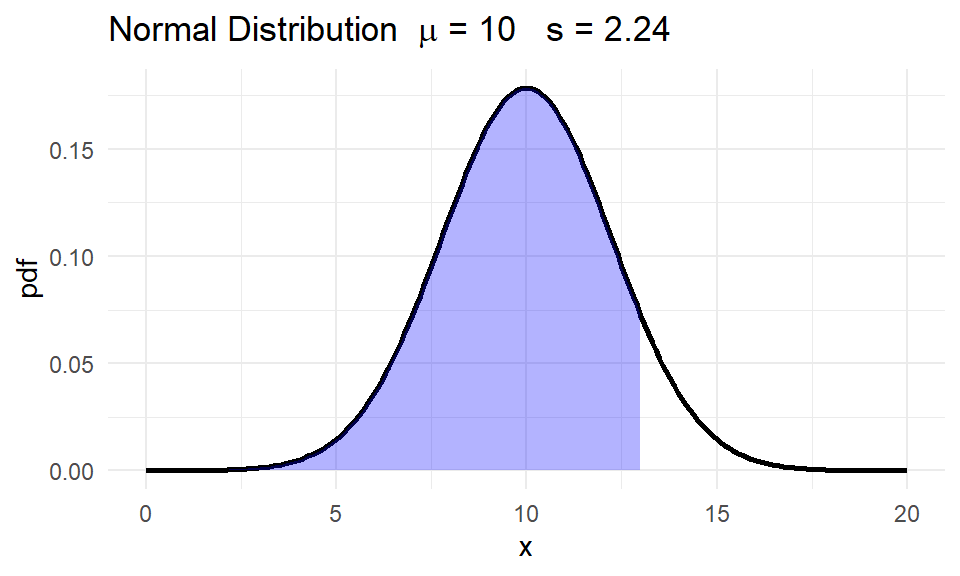

**Example:**

What is $P(X \le 13)$ for $X \sim \text{N}(10,2.24)$?
$$\begin{aligned}
P(X \le 13) & = \int_0^{13} f(x) \ dx \\
& = \int_0^{13} \frac{1}{\sqrt{2 \pi (2.24)^2}}
e^{-\frac{(x-10)^2}{2(2.24)^2}} \ dx \\
P(X \le 13) & \approx 0.9098
\end{aligned}$$

**Using R:**

```r
mu <- 10
sd <- 2.24
pnorm(13,mu,sd)
```

```
## [1] 0.9097612
```

$\star$ Note that the `pnorm()` function computes the probability $P(X \le x)$, meaning it computes the area under $f(x)$ from $X=0$ to $X=x$ using the Normal PDF. The `dnorm()` function computes the density, not probability because $P(X = x)=0$ at any $x$.

# Normal Expected Value

**Normal Distribution with Expected Value**

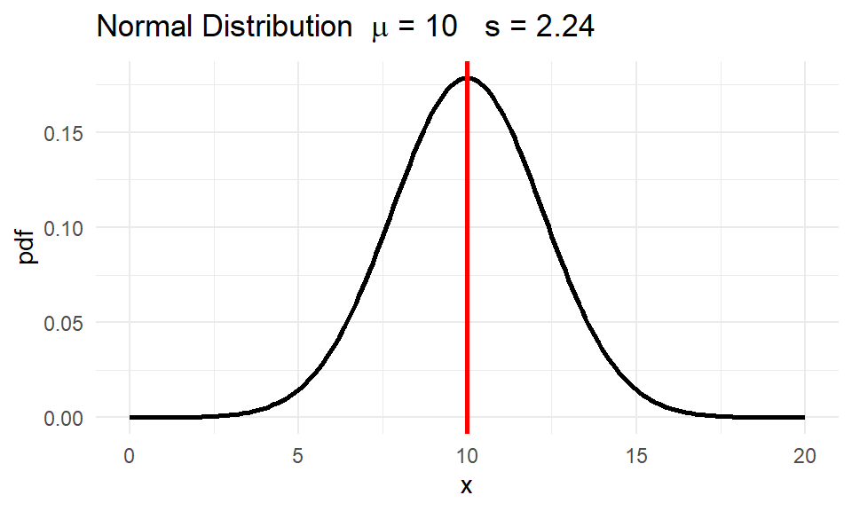

**Normal R.V.**

Let $\mu=10$ and $s=2.24$ be the mean and standard deviation respectively.

$$\begin{aligned}
\text{R.V. } & \longrightarrow X \sim \text{N}\left(10,2.24^2\right)
\\
\text{PDF } & \longrightarrow f(x) = \frac{1}{\sqrt{2 \pi (2.24)^2}}
e^{-\frac{(x-10)^2}{2(2.24)^2}} \\
\text{for } & x \in (-\infty,\infty) \\
\text{expected value} & \longrightarrow \text{E}(X) = 10
\end{aligned}$$

In general, the expected value of the normal r.v. is given by
$$\text{E}(X) = \mu,$$
which is the center of the normal distribution.

# Simulating the Normal Distribution

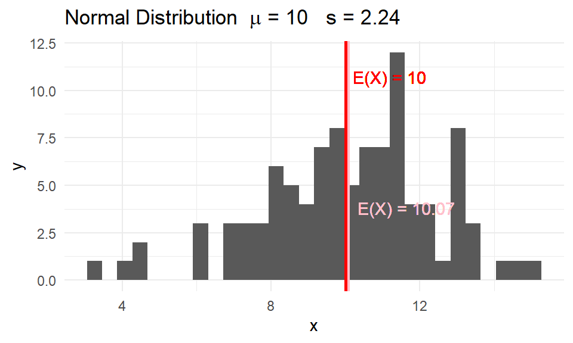

**Sample Mean vs the Expected Value**

The sample mean of $10.07$ is not exactly equal to the expected value of $10$ due to sampling variability. As we increase the number of samples, the sample mean gets closer to the expectation.

**Normal Random Sampling using R**

```r
N <- 100 # number of simulations
mu <- 10
sd <- 2.24
rnorm(N,mu,sd)
```

# Normal Approximation to the Binomial (Revisited)

**When Can we use it?**

The binomial distribution $X \sim \text{Binom}(n,p)$ can be approximated by a normal distribution when:

**Approximation Formula**

- If $X \sim \text{Binom}(n,p)$, then for large $n$,
  $$X \approx \text{N}(\mu,\sigma^2)$$
  where $\mu = np$ and $\sigma^2 = np(1-p)$.

$\star$ The normal approximation simplifies binomial probability calculations for large $n$.

# Why Use Normal Approximation for Binomial?

- **Computational convenience:** Calculating binomial probabilities for large $n$ can be computationally intense because you have to evaluate a large number of terms. The normal approximation simplifies this by allowing you to use the normal distribution.
- **Simplifies calculations:** When $n$ is large, the binomial distribution can become cumbersome to work with directly. The normal approximation provides a simpler alternative that still gives reasonably accurate results.

# Exponential vs Normal Distribution Summary

| **R.V.** $X$ | **Exponential** | **Normal** |
| --- | --- | --- |
| *Description* | Unit length until a “success” event happens | Approximation to the Binomial with sufficiently large number of $n$ independent trials |
| *Sampling* | With replacement | With replacement |
| *Parameters* | $\lambda \longrightarrow$ rate of “success” | $\mu \longrightarrow$ mean $\sigma^2 \longrightarrow$ variance |
| *PMF* | $f(x) = f(x) = \lambda e^{- \lambda x}$ $x \in [0,\infty)$ | $f(x) = \frac{1}{\sqrt{2 \pi \sigma^2}} e^{-\frac{(x-\mu)^2}{2\sigma^2}}$ $x \in (-\infty,\infty)$ |
| *Expected Value* $\text{E}(X)$ | $\frac{1}{\lambda}$ | $\mu$ |
| $P(X = x)$ | `dexp(rate)` | `dnorm(mean,sd)` |
| $P(X \le x)$ | `pexp(rate)` | `pnorm(mean,sd)` |
| $N$ *Simulations* | `rexp(N,rate)` | `rnorm(N,mean,sd)` |

# Activity: The Galton Board and the Normal Distribution

1. Watch this video: https://youtu.be/UCmPmkHqHXk?si=LT1apiUwe0meA8PS.
2. Get together with another student.
3. Discuss the video by answering the following question.
   - How does the structure of Pascal’s triangle relate to the binomial distribution?
   - Why does the shape of the bead distribution on a Galton board become approximately normal as the number of rows increases?
4. Make sure to write your name in the attendance sheet.

# References

Diez, D. M., Barr, C. D., & Çetinkaya-Rundel, M. (2012). *OpenIntro statistics* (4th ed.). OpenIntro. https://www.openintro.org/book/os/

Speegle, Darrin and Clair, Bryan. (2021). *Probability, statistics, and data: A fresh approach using r*. Chapman; Hall/CRC. https://probstatsdata.com/

# Appendix: The Binomial Coefficient

**Pascal’s Triangle and Combinations** This formula calculates the number of ways to choose $k$ elements from a set of $n$. Each number in Pascal’s Triangle corresponds to a combination. Also known as the **binomial coefficient**.

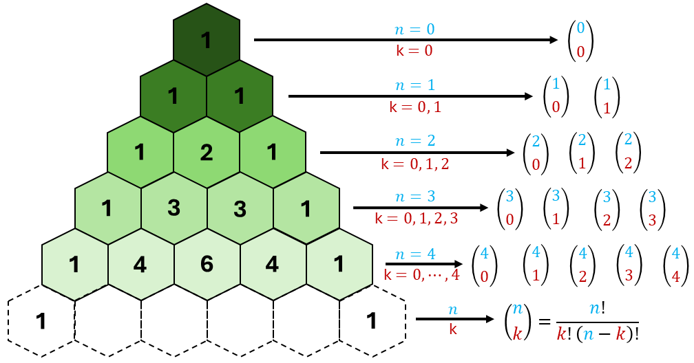